# Text Prediction in R with a Katz Backoff Model

March 26, 2017

## Algorithm Overview

Part 1: Constructing N-Gram Tables

1. Using 10% of each supplied data set (blogs, news, and Twitter), clean the data and split into N-gram tokens up to 4 grams
2. Convert the tokens to integers and use them to create N-gram lookup tables for 4-gram, 3-gram, and 2-gram tokens

Part 2: Predicting Given a New Phrase

1. Clean the supplied phrase, take the final 3 words, and convert them to integers for table lookup
2. Find matches in all N-gram tables, discarding any that would predict a "stop word"
3. Using a Katz Backoff Model, assign probabilities and return the top predictions

## Algorithm Performance

I tested both the predictive accuracy of the top prediction, and whether the correct prediction was contained in the top 5 as follows:

1. Take a new sample of the supplied data and run the algorithm on each phrase, leaving out the last word.
2. Compare each top prediction to the real last word to get "Predictive Accuracy""
3. Check if each list of the top 5 predictions contains the real last word to get "Top 5 Accuracy"

Based on this procedure, my algorithm produced the following metrics:

- **Predictive accuracy: 13.2%**
- **Top 5 accuracy: 25.1%**

## Demonstration of Algorithm Output

For example, we can try looking up the phrase "Once upon a"

```r
phrase <- "Once upon a"
predict.word <- predictNextWord(phrase, table.list)
print(predict.word[[1]])
```

```
## [1] "time"
```

```r
predict.word[[2]][1:5,]
```

```
##      Word Probability
## 1    time  0.74015087
## 4   price  0.01850609
## 2    work  0.01849990
## 3 working  0.01847053
## 5   fixed  0.01844424
```

## The Web Interface

The web interface is relatively simple:

- Enter a phrase into the text box and click "Submit Phrase"
- Observe your results, including an illustrative barplot:

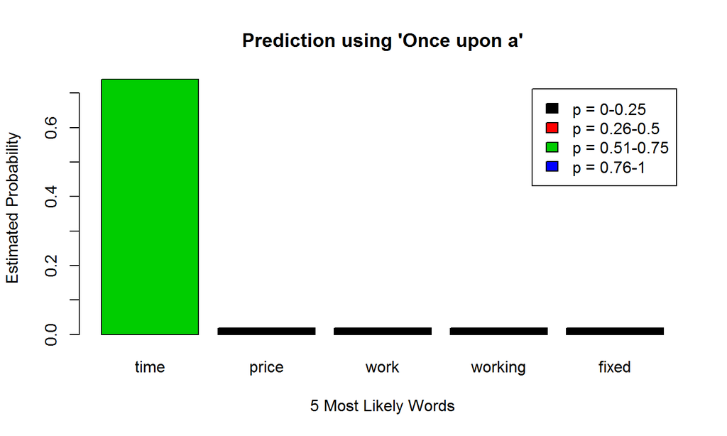